### Estimation et élagage d’un arbre de discrimination

Dans le cas d’une discrimination, le critère par défaut est l’indice de concentration de Gini ; il est possible de préciser un autre critère (split=“information”) ainsi que des poids sur les observations, une matrice de coûts de mauvais classement ainsi que des probabilités a priori (`?rpart` pour plus de détails).

**Question** Quel autre critère d’hétérogénéité est utilisé ?

**Réponse**

L’entropie est un autre critère d’hétérogénéité couramment utilisé pour la construction d’arbres de décision. Il est utilisée pour évaluer la pureté des noeuds d’un arbre de décision

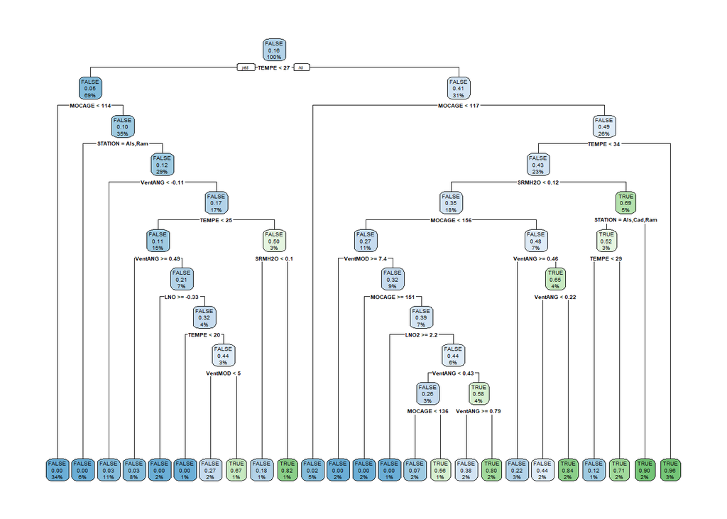

```r
tree.dis=rpart(DepSeuil~.,data=datappq,parms=list(split="information"),cp=0.001)
rpart.plot(tree.dis)
```

La même procédure d’élagage par validation croisée est mise en place mais avec une expression différente de l’erreur de prévision: taux de mal classés plutôt qu’erreur quadratique.

```r
xmat = xpred.rpart(tree.dis)
# Comparaison des valeurs prédite et observée
xerr=datappq$DepSeuil!= (xmat>1.5)
# Calcul  des estimations des taux d'erreur
CVerr=apply(xerr, 2, sum)/nrow(xerr)
CVerr
```

```
## 0.525925926 0.045961754 0.030089031 0.018144368 0.012394963 0.009799079
##   0.1622596   0.1322115   0.1286058   0.1310096   0.1394231   0.1418269
## 0.008281733 0.002721655
##   0.1466346   0.1538462
```

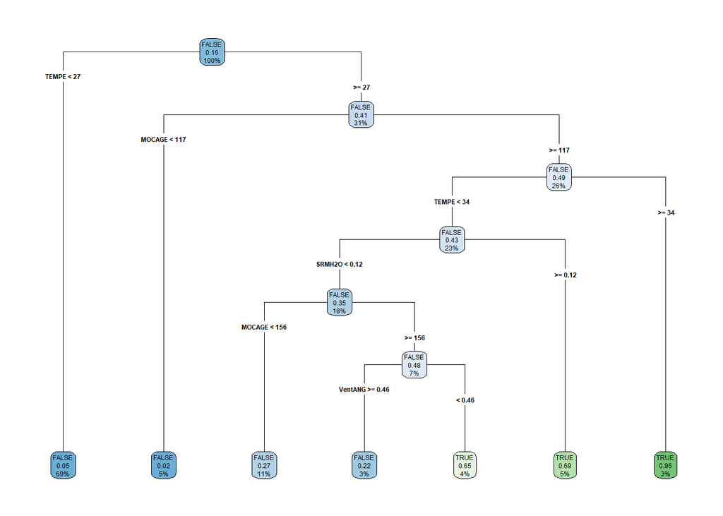

```r
tree.dis=rpart(DepSeuil~.,data=datappq,parms=list(split="information"),cp=as.numeric(attributes(which.min(CVerr))$names))
rpart.plot(tree.dis,type=4)
```

Avec la librairie `caret`:

```r
library(caret)
ctrl <- trainControl(method = "cv",number = 10)
treecaret <- train(DepSeuil~.,data=datappq,method = "rpart",trControl = ctrl,tuneLength =20,metric="Accuracy")
print(paste("Valeur de cp retenue = ",treecaret$bestTune,sep=""))
```

```
## [1] "Valeur de cp retenue = 0.0192982456140351"
```

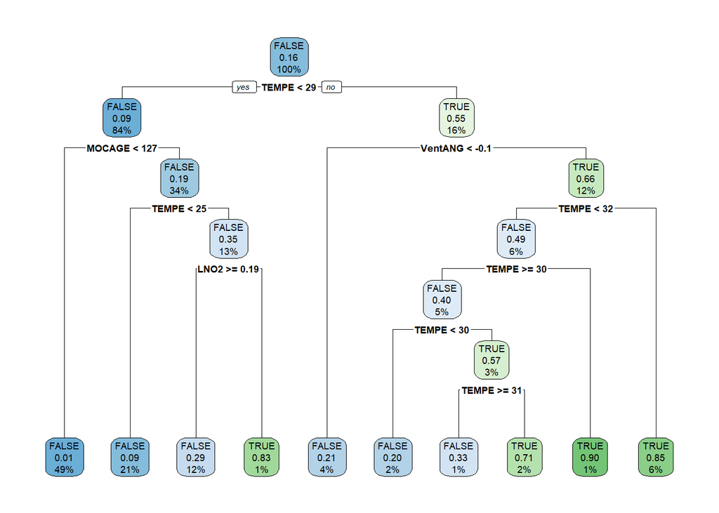

```r
rpart.plot(treecaret$finalModel)
```

### Prévision de l’échantillon test

Différentes prévisions sont considérées assorties des erreurs estimées sur l’échantillon test. Prévision quantitative de la concentration, prévision de dépassement à partir de la prévision quantitative et directement la prévision de dépassement à partir de l’arbre de décision.

#### Erreur de régression

```r
# Calcul des prévisions
pred.treer=predict(tree.reg,newdata=datestr)
# Erreur quadratique moyenne de prévision en régression
sum((pred.treer-datestr[,"O3obs"])^2)/nrow(datestr)
```

```
## [1] 732.8636
```

#### Erreur de classification (matrice de confusion)

```r
# Matrice de confusion pour la prévision du
# dépassement de seuil (régression)
  #table(pred.treer>150,datestr[,"O3obs"]>150)
confusionMatrix(as.factor(pred.treer>150),as.factor(datestr[,"O3obs"]>150))$table
```

```
##           Reference
## Prediction FALSE TRUE
##      FALSE   160   19
##      TRUE      6   24
```

```r
# Même chose pour l'arbre de discrimination
pred.treeq=predict(tree.dis,newdata=datestq,type="class")
  #table(pred.treeq,datestq[,"DepSeuil"])
confusionMatrix(pred.treeq,datestq[,"DepSeuil"])$table
```

```
##           Reference
## Prediction FALSE TRUE
##      FALSE   162   22
##      TRUE      4   21
```

**Question** Quelle stratégie semble meilleure à ce niveau ?

**Réponse**

Exactitude = (VP+VN ) / (VP + VN + FP + FN)

Précision = VP / (VP + FP)

Rappel = VP / (VP + FN)

Arbre de discrimination

VP (Vrais Positifs) = 21 VN (Vrais Négatifs) = 162 FP (Faux Positifs) = 4 FN (Faux Négatifs) = 22

Exactitude = 0.8756

Précision = 0.84

Rappel = 0.4884

#### Courbes ROC

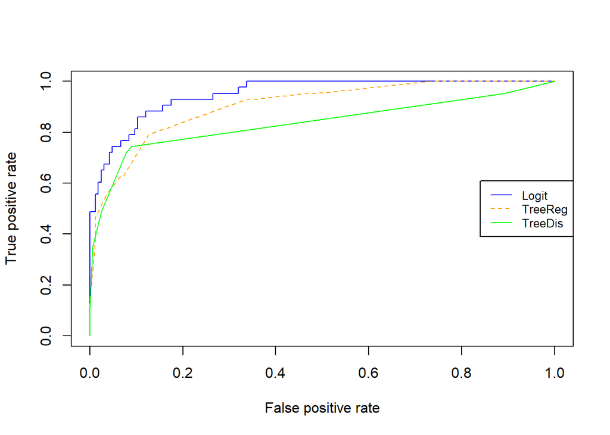

```r
ROCregtree=pred.treer/300
predregtree=prediction(ROCregtree,datestq$DepSeuil)
perfregtree=performance(predregtree,"tpr","fpr")
ROCdistree=predict(tree.dis,newdata=datestq,type="prob")[,2]
preddistree=prediction(ROCdistree,datestq$DepSeuil)
perfdistree=performance(preddistree,"tpr","fpr")
# tracer les courbes ROC en les superposant
# pour mieux comparer

options(repr.plot.width = 8, repr.plot.height = 6)
plot(perflogit,col="blue")
plot(perfregtree,col="orange",lty=2,add=TRUE)
plot(perfdistree,col="green",add=TRUE)

legend("right", legend=c("Logit", "TreeReg", "TreeDis"),
       col=c("blue","orange","green"), lty=c(1,2,1), text.font=1,    cex=0.8)
```

**Question** Comparez les qualités de prévision. Une meilleure méthode se dégage-t-elle ?

**Réponse**

La régression logistique (Logit) semble etre la méthode la plus performante pour de la prévision car sa courbe est la plus proche du coin supérieur gauche, ainsi il est donc la meilleure méthode, suivie de près par l’arbre de régression (TreeReg). L’arbre de classification (TreeDis) est moins performant que les deux autres.

# Épisode 4 : Réseaux de neurones

## [Réseau de neurones](http://wikistat.fr/pdf/st-m-app-rn.pdf)

### Introduction

Il s’agit d’estimer un modèle de type *perceptron* avec en entrée les variables qualitatives ou quantitatives et en sortie la variable à prévoir. Des fonctions R pour l’apprentissage d’un perceptron élémentaire ont été réalisées par différents auteurs et sont accessibles sur le réseau. La librairie `nnet` de (Ripley, 1999), est limitée au perceptron à une couche. Ce n’est pas de l’*apprentissage profond* ! mais suffisant dans bien des cas. Une librairie R associée au logiciel éponyme H2O propose des réseaux à plusieurs couches et “convolutionnels”.

Comme pour les arbres, la variable à expliquer est soit quantitative soit qualitative ; la fonction de transfert du neurone de sortie d’un réseau doit être adaptée en conséquence.

**Question** Quelle fonction de transfert est utilisée pour le dernier neurone en régression ? en classification binaire? en classification multiclasse ?

**Réponse** - En régression : La fonction de transfert utilisée est généralement la fonction d’identité (ou fonction linéaire). Cela signifie que la sortie du neurone est directement proportionnelle à la somme pondérée de ses entrées, ce qui permet de prédire des valeurs continues.

- En classification binaire : La fonction de transfert est la fonction sigmoïde (ou logistique). Elle transforme la sortie du neurone en une probabilité comprise entre 0 et 1, ce qui est adapté pour classer les observations en deux catégories.
- En classification multiclasse : On utilise souvent la fonction softmax. Cette fonction transforme les sorties du neurone en probabilités pour chaque classe, de sorte que la somme des probabilités de toutes les classes soit égale à 1. Cela permet de classer les observations dans l’une des plusieurs catégories possibles.

**Question** Quel est le choix par défaut pour les neurones de la couche cachée?

**Réponse**

la fonction d’activation par défaut pour les neurones de la couche cachée est généralement la sigmoïde

Différentes stratégies sont proposées pour éviter le sur-apprentissage. La première consiste à optimiser le nombre de neurones sur la couche cachée. Très approximativement il est d’usage de considérer, qu’en moyenne, il faut une taille d’échantillon d’apprentissage 10 fois supérieure au nombre de poids c’est-à-dire au nombre de paramètres à estimer. On remarque qu’ici la taille de l’échantillon d’apprentissage (832) est modeste pour une application raisonnable du perceptron. Seuls des nombres restreints de neurones peuvent être considérés et sur une seule couche cachée.

**Question** Quel est le paramètre `decay` de la fonction `nnet`?

**Réponse**

Le paramètre decay est crucial pour contrôler la régularisation dans le modèle de perceptron, ce qui permet de limiter le sur-apprentissage et d’améliorer la généralisation du modèle sur de nouvelles données.

**Question** Indiquez une autre façon d’éviter le sur-apprentissage.

**Réponse**

La validation croisée est une méthode efficace pour évaluer la performance d’un modèle et réduire le risque de sur-apprentissage, en garantissant que le modèle apprend de manière à bien généraliser sur des données nouvelles.

### Cas de la régression

```r
library(MASS)
library(nnet)
# apprentissage
# attention au paramètre linout dans le cas de la régression
nnet.reg=nnet(O3obs~.,data=datappr,size=5,decay=1,linout=TRUE,maxit=500)
summary(nnet.reg)
```

```
## a 12-5-1 network with 71 weights
## options were - linear output units  decay=1
##   b->h1  i1->h1  i2->h1  i3->h1  i4->h1  i5->h1  i6->h1  i7->h1  i8->h1  i9->h1
##   -5.47    0.56   -0.01    0.33   -1.29    0.14    1.85    0.97    0.25   -0.01
## i10->h1 i11->h1 i12->h1
##  -21.80    1.23   -1.32
##   b->h2  i1->h2  i2->h2  i3->h2  i4->h2  i5->h2  i6->h2  i7->h2  i8->h2  i9->h2
##   10.19    2.03    0.28    0.27  -14.69    1.92  -12.52    7.54   -0.06    5.64
## i10->h2 i11->h2 i12->h2
##  -17.80  -33.45   17.49
##   b->h3  i1->h3  i2->h3  i3->h3  i4->h3  i5->h3  i6->h3  i7->h3  i8->h3  i9->h3
##    9.19   -1.11    0.13    0.11    2.28    3.62   -1.47   -0.74   -0.52   -0.13
## i10->h3 i11->h3 i12->h3
##   -5.65  -15.51   15.63
##   b->h4  i1->h4  i2->h4  i3->h4  i4->h4  i5->h4  i6->h4  i7->h4  i8->h4  i9->h4
##    0.85    0.61   -0.02    0.10   -1.39    1.30   -1.62    2.43    0.27    0.10
## i10->h4 i11->h4 i12->h4
##    7.34   -3.89    1.76
##   b->h5  i1->h5  i2->h5  i3->h5  i4->h5  i5->h5  i6->h5  i7->h5  i8->h5  i9->h5
##  -21.96    0.36   -0.03    0.54    1.19    0.03    4.22    0.80    0.07    0.26
## i10->h5 i11->h5 i12->h5
##   26.42    2.89   -2.11
##   b->o  h1->o  h2->o  h3->o  h4->o  h5->o
##  38.52  57.43  24.10  36.65 -40.05  92.42
```

La commande donne la “trace” de l’exécution avec le comportement de la convergence mais le détail des poids de chaque entrée de chaque neurone ne constitue pas un résultats très explicite !

**Question** Contrôlez le nombre de poids estimés.

**Réponse**

Poids des entrées aux neurones cachés: 12 entrées * 5 neurones cachés = 60 poids Biais pour chaque neurone caché: 5 biais Poids des neurones cachés au neurone de sortie: 5 neurones cachés * 1 neurone de sortie = 5 poids Biais pour le neurone de sortie: 1 biais, 71 poids,

L’optimisation des paramètres nécessite encore le passage par la validation croisée. Il n’y a pas de fonction dans la librairie `nnet` permettant de le faire mais la fonction `tune.nnet` de la librairie `e1071` est adaptée à cette démarche.

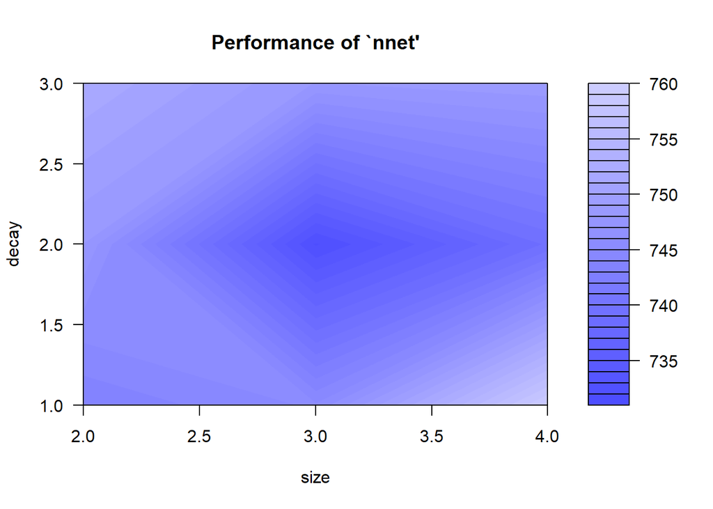

```r
library(e1071)
plot(tune.nnet(O3obs~.,data=datappr,size=c(2,3,4),decay=c(1,2,3),maxit=200,linout=TRUE))
```

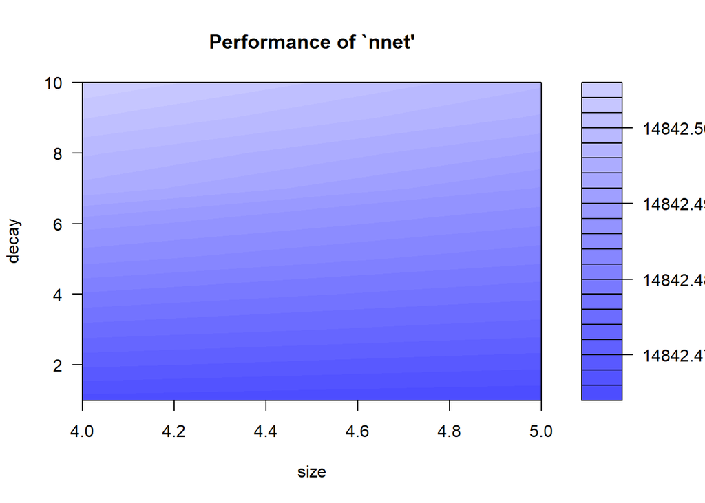

```r
plot(tune.nnet(O3obs~.,data=datappr,size=4:5,decay=1:10))
```

Faire éventuellement varier la grille des paramètres (zoom), notez la taille et le `decay` optimaux. Il faudrait aussi faire varier le nombre total d’itérations. Cela risque de prendre un peu de temps ! Notez également que chaque exécution donne des résultats différents… il n’est donc pas très utile d’y passer beaucoup de temps !

**Question** Ré-estimez le modèle supposé optimal avant de tracer le graphe des résidus.

```r
nnet.reg=nnet(O3obs~.,data=datappr,size=3,decay=2,linout=TRUE,maxit=200)
```

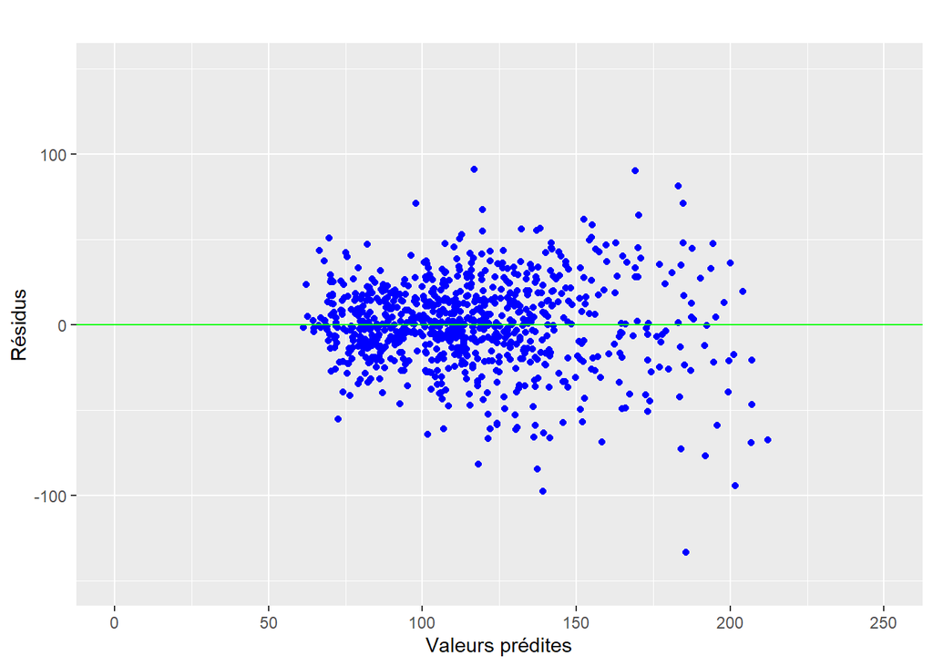

```r
# calcul et graphe des résidus
fit.nnetr=predict(nnet.reg,data=datappr)
res.nnetr=fit.nnetr-datappr[,"O3obs"]
gplot.res(fit.nnetr,res.nnetr,titre="")
```

### Cas de la discrimination

```r
# apprentissage
nnet.dis=nnet(DepSeuil~.,data=datappq,size=5,decay=0)
summary(nnet.reg)
```

```
## a 12-3-1 network with 43 weights
## options were - linear output units  decay=2
##   b->h1  i1->h1  i2->h1  i3->h1  i4->h1  i5->h1  i6->h1  i7->h1  i8->h1  i9->h1
##  -10.90    0.07    0.01    0.32    0.92    0.73    1.65    0.14   -0.08    0.17
## i10->h1 i11->h1 i12->h1
##   20.64   -1.58    1.91
##   b->h2  i1->h2  i2->h2  i3->h2  i4->h2  i5->h2  i6->h2  i7->h2  i8->h2  i9->h2
##    0.00    0.00    0.21    0.02    0.00    0.00    0.00    0.00    0.01    0.00
## i10->h2 i11->h2 i12->h2
##    0.00    0.01    0.00
##   b->h3  i1->h3  i2->h3  i3->h3  i4->h3  i5->h3  i6->h3  i7->h3  i8->h3  i9->h3
##    0.21    0.08    0.04    0.07   -1.30   -0.41    0.61   -0.64   -0.16    0.28
## i10->h3 i11->h3 i12->h3
##  -26.86   -1.01    0.76
##   b->o  h1->o  h2->o  h3->o
##  28.77 107.00  28.54  55.82
```

La validation croisée est toujours nécessaire afin de tenter d’optimiser les choix en présence : nombre de neurones, `decay` et éventuellement le nombre maximal d’itérations.

L’initialisation de l’apprentissage d’un réseau de neurone comme celle de l’estimation de l’erreur par validation croisée sont aléatoires. Chaque exécution donne donc des résultats différents. À ce niveau, il serait intéressant de construire un plan d’expérience à deux facteurs (ici, les paramètres de taille et `decay`) de chacun trois niveaux. Plusieurs réalisations pour chaque combinaison des niveaux suivies d’un test classique d’anova permettraient de se faire une idée plus juste de l’influence de ces facteurs sur l’erreur.

**Question** Notez la taille et le `decay` optimaux et ré-estimez le modèle pour ces valeurs.

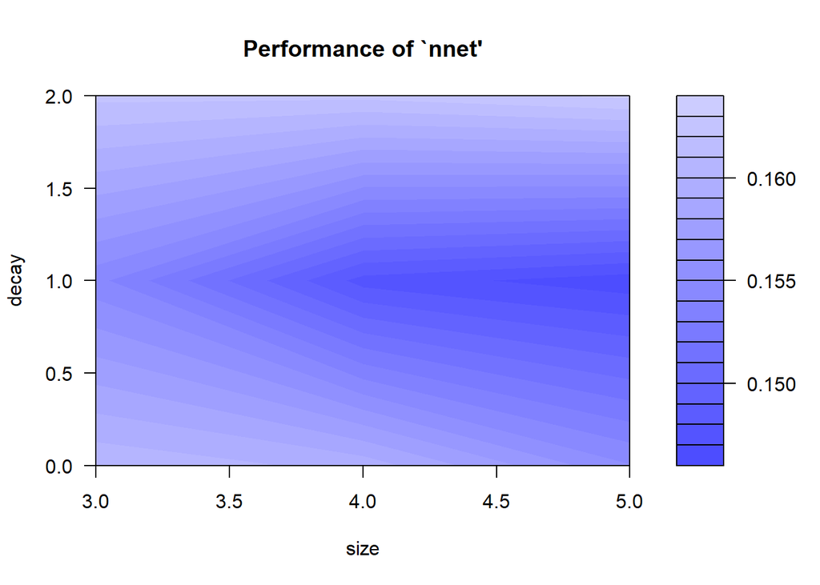

```r
plot(tune.nnet(DepSeuil~.,data=datappq,size=c(3,4,5),decay=c(0,1,2),maxit=200,linout=FALSE))
```

```r
nnet.dis=nnet(DepSeuil~.,data=datappq,size=5,decay=1)
```

### Prévisions de l’échantillon test

Différentes prévisions sont considérées assorties des erreurs estimées sur l’échantillon test. Prévision quantitative de la concentration, prévision de dépassement à partir de la prévision quantitative et directement la prévision de dépassement à partir de l’arbre de décision.

#### Erreur de régression

```r
# Calcul des prévisions
pred.nnetr=predict(nnet.reg,newdata=datestr)
pred.nnetq=predict(nnet.dis,newdata=datestq)
# Erreur quadratique moyenne de prévision
sum((pred.nnetr-datestr[,"O3obs"])^2)/nrow(datestr)
```

```
## [1] 571.5625
```

#### Erreur de classification (matrice de confusion)

```r
# Matrice de confusion pour la prévision du
# dépassement de seuil (régression)
table(pred.nnetr>150,datestr[,"O3obs"]>150)
```

```
##
##         FALSE TRUE
##   FALSE   160   22
##   TRUE      6   21
```

```r
confusionMatrix(as.factor(pred.nnetr>150),as.factor(datestr[,"O3obs"]>150))$table
```

```
##           Reference
## Prediction FALSE TRUE
##      FALSE   160   22
##      TRUE      6   21
```

```r
# Même chose pour la discrimination
table(pred.nnetq>0.5,datestq[,"DepSeuil"])
```

```
##
##         FALSE TRUE
##   FALSE   165   32
##   TRUE      1   11
```

#### Courbes ROC

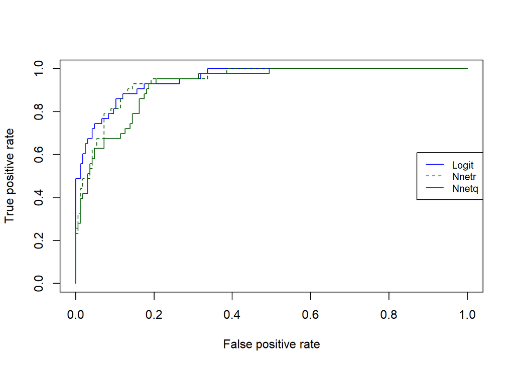

```r
library(ROCR)


roclogit <- predict(log.qm.step1, newdata = datestq, type="response")
predlogit <- prediction(roclogit, datestq[, "DepSeuil"])
perflogit <- performance(predlogit, "tpr", "fpr")


rocnnetr=pred.nnetr/300
prednnetr=prediction(rocnnetr,datestq$DepSeuil)
perfnnetr=performance(prednnetr,"tpr","fpr")

rocnnetq=pred.nnetq
prednnetq=prediction(rocnnetq,datestq$DepSeuil)
perfnnetq=performance(prednnetq,"tpr","fpr")

# tracer les courbes ROC en les superposant pour mieux comparer
plot(perflogit,col="blue")
plot(perfnnetr,col="darkgreen",lty=2,add=TRUE)
plot(perfnnetq,col="darkgreen",add=TRUE)
legend("right", legend=c("Logit", "Nnetr", "Nnetq"),
       col=c("blue","darkgreen", "darkgreen"), lty=c(1,2,1), text.font=1,    cex=0.8)
```

**Question** Une méthode semble-t-elle significativement meilleure?

**Réponse**

La courbre Logit ce demarque legerement au niveau des True positive lorsque le False positive rate est proche de 0, mais lorque l’on suit l’evolution des trois courbes, a partir d’un certain taux de False positive (0.3), les trois courbes se chevauche. Cela montre une performances similaires entre les trois modèles.